# ARRA Analysis: NYC

ARRA was passed on 2009-02-17

> “Making supplemental appropriations for job preservation and creation, infrastructure investment, energy efficiency and science, assistance to the unemployed, and State and local fiscal stabilization, for the fiscal year ending September 30, 2009, and for other purposes.
> 1. Statement of Purposes.–The purposes of this Act include the following:
> 1. To preserve and create jobs and promote economic recovery.
> 2. To assist those most impacted by the recession.
> 3. To provide investments needed to increase economic efficiency by spurring technological advances in science and health.
> 4. To invest in transportation, environmental protection, and other infrastructure that will provide long-term economic benefits.
> 5. To stabilize State and local government budgets, in order to minimize and avoid reductions in essential services and counterproductive state and local tax increases.

## Ideas for the future

ARRA had several goals

Recovery (job creation)

Relief (assist those most struggling, stabilize state and local budgets)

- Where was the city budget supplemented, where was it displaced?
- What was the job market like in NYC before and after the ARRA funding (unemployment, number of jobs, type of jobs)?

Reinvestment (infrastructure, education, and environment)

- What was built? What were the investments in education?

Responsibility (Regular reporting, transparency)

- Check payment dates, contract dates, large lump sum payments

Low hanging fruit

- recreate the NYC council’s midway report with the final data.

Higher up fruit

- Was the ARRA funding supplemented with city funding for larger projects?
- What was the distribution of funding by sector? and what were the biggest projects in each sector?
- Mine Payment Description (text field) by sector to see what the money was being used on?

```r
# Load Packages
# First we will install a package manager: pacman
if (!require("pacman")) {install.packages("pacman")}
```

```r
# And then we will use pacman to check if the other needed packages are installed and install if necessary

# Data manipulation
pacman::p_load(tidyverse) # General R improvements includes stringr, dplyr
pacman::p_load(lubridate) # date manipulation
pacman::p_load(stringi) # string processing, has some functions that work better than stringr
# pacman::p_load(data.table)   # extension of data.frame, has in-place replacement
pacman::p_load(countrycode) # converts country names to country codes, used in affiliation reconciliation

# Data access
pacman::p_load(filesstrings) # make and edit files/folders
pacman::p_load(httr) # api access
pacman::p_load(xml2) # xml access and parsing
pacman::p_load(jsonlite) # JSON interpreter
pacman::p_load(readxl) # read in excel files

# Data visualization
pacman::p_load(ggplot2) # plotting package, not used currently but can be used to look at the networks visually
pacman::p_load(scales) # plotting package, extends ggplot2
# pacman::p_load(RColorBrewer)

# Misc
pacman::p_load(igraph) # networks: creation, transformation, etc

# Restart R session if you install new packages
# .rs.restartR()
```

Next we have to point to where the data lives in the repository. It is in a ./Data/ folder but in not in the git repo. The data can be found on [kaggle](https://www.kaggle.com/datasets/new-york-city/nyc-use-of-arra-stimulus-funds?resource=download) or on NYC’s city [OpenData webpage](https://data.cityofnewyork.us/City-Government/Use-of-ARRA-Stimulus-Funds/ivix-m77e)

The dataset covers the use of funds from the American Recovery and Reinvestemnt Act of 2009. The dataset was originally made public in 2011. It was last updated in 2018 and the metadata was last updated in 2022.

```r
dataFolder <- "./Data/"

ArraDataFile <- "use-of-arra-stimulus-funds.csv"
ArraJSONFile <- "socrata_metadata.json"
ArradDictionaryFile <- "Data_Dictionary_Use_of_ARRA_Stimulus_Funds.xlsx"
```

## Load data

```r
# Read in the data file
arraData <- read.csv(file = paste0(dataFolder, ArraDataFile)) %>% as_tibble
# I'm choosing to import and convert to tibble to make use of dplyr's filtering and ease of use with ggplot2
# I could also have used data.table which has better in place replacement but since this dataset is not huge and I do not expect to need in place replacement, tibble's are a better fit.


# Read in the metadata file
arraMetaData <- read_json(path = paste0(dataFolder, ArraJSONFile), simplifyVector = FALSE)
```

Some initial thoughts There are 279 unioque tracked projects in 8 categories. Awards were awarded through 25 city agencies.

There are 13553 rows. The unique id column in each row is the Paymend ID with 1.314^{4} unique entries and 413 with no value.

Convert date columns from strings to dates.

```r
arraData$Actual.Completion.Date <- arraData$Actual.Completion.Date %>% as_date()
arraData$Date.Funds.Awarded.by.Fed.State <- arraData$Date.Funds.Awarded.by.Fed.State %>% as.Date()
arraData$Actual.Start.Date <- arraData$Actual.Start.Date %>% as.Date()
arraData$Payment.Date <- arraData$Payment.Date %>% as.Date()
```

```r
completionCounts <- count(arraData, Actual.Completion.Date)%>%
  arrange(desc(n) )

completionCounts
```

```
## # A tibble: 14 x 2
##    Actual.Completion.Date     n
##    <date>                 <int>
##  1 NA                     12898
##  2 2010-04-15               362
##  3 2010-06-30               201
##  4 2009-12-18                34
##  5 2010-01-26                10
##  6 2010-05-18                 9
##  7 2010-06-28                 7
##  8 2010-09-30                 7
##  9 2010-05-24                 6
## 10 2011-04-07                 6
## 11 2010-06-01                 5
## 12 2010-03-17                 4
## 13 2009-10-31                 2
## 14 2010-06-17                 2
```

```r
# monthdf <- tibble(Month = month(arraData$Actual.Completion.Date),
#                   Year = year(arraData$Actual.Completion.Date))
#
# ggplot(monthdf) +
#   geom_histogram(aes(x = Month),
#                  breaks=seq(1, 12, by = 1),
#                  colour="black",
#                  fill="purple"
#   )
#
# ggplot(datedf) +
#   geom_histogram(aes(x = Year),
#                  breaks=seq(2008, 2022 , by = 1),
#                  colour="black",
#                  fill="purple"
#   )
```

```r
arraCompleted <- arraData %>% filter(Project.Status == "Fully Completed"  )

LargePayments <- arraCompleted %>% filter(Payment.Value > 1000000)

(LargePayments$Payment.Value/1000000) %>% sort(decreasing = TRUE)
```

```
##  [1] 79.818560 16.103431  7.739825  7.660311  6.965945  2.709218  1.965506
##  [8]  1.596320  1.499775  1.018329
```

Only 13 projects are listed as “Fully Completed.” 10 of them had payments over 1 million dollars and those payments come from 6 different projects.

```r
stimIdSum <- arraData %>%
  filter(is.na(Payment.Id)==FALSE) %>%
  group_by(Stimulus.Tracker.ID,Funding.Category) %>%
  summarise(TotalMoney = sum(Payment.Value), .groups= "keep") %>%
  arrange(desc(TotalMoney) )

head(stimIdSum)
```

```
## # A tibble: 6 x 3
## # Groups:   Stimulus.Tracker.ID, Funding.Category [6]
##   Stimulus.Tracker.ID Funding.Category           TotalMoney
##                 <dbl> <chr>                           <dbl>
## 1              801001 Medicaid Relief*          1339053641
## 2              501003 Education                  431514497.
## 3              413001 Health and Social Support  395721477
## 4              501001 Education                  263667687.
## 5              501002 Education                  108895867.
## 6              416002 Health and Social Support   81443040
```

Recreate one of the pie charts from the midterm report. This is pie chart covers the distribution of the funds over the eight sectors

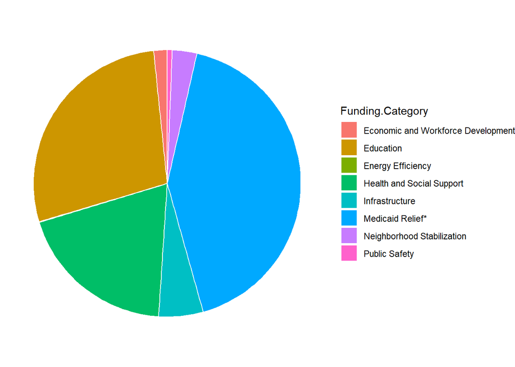

```r
stimIdSum %>%
  group_by(Funding.Category) %>%
  summarize(Money = sum(TotalMoney)) %>%
  ggplot( aes(x="", y=Money, fill=Funding.Category ))+
  geom_bar(stat="identity", width=1, color="white") +
  coord_polar("y", start=0) +
  theme_void() # remove background, grid, numeric labels
```

Which we can compare to the number of payments made to get a sense of whether the payments were in large lump sums or more spread out.

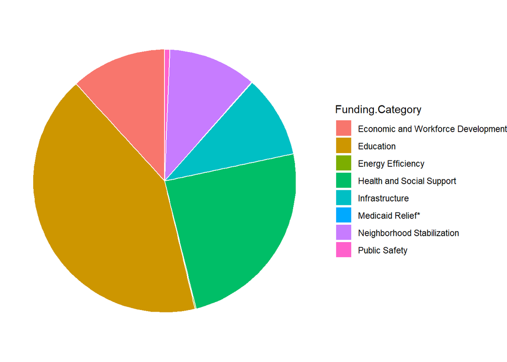

```r
arraData %>%
  filter(is.na(Payment.Id)==FALSE) %>%
  count(Funding.Category)  %>%
  ggplot( aes(x="", y=n, fill=Funding.Category ))+
  geom_bar(stat="identity", width=1, color="white") +
  coord_polar("y", start=0) +
  theme_void() # remove background, grid, numeric labels
```

The ordert of the funding categories is the same in the two pie charts. Medicaid relief for being the largest category was done is 8 payments.

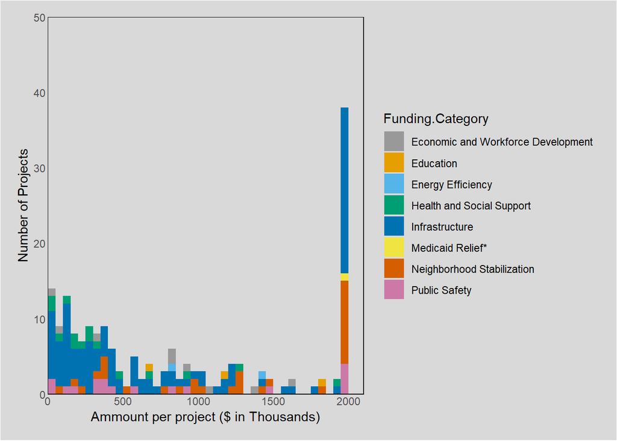

```r
# Add a color blind friendly palette
# ref: http://www.cookbook-r.com/Graphs/Colors_(ggplot2)/#a-colorblind-friendly-palette
cbPalette <- c("#999999", "#E69F00", "#56B4E9", "#009E73",  "#0072B2","#F0E442", "#D55E00", "#CC79A7")


stimIdSum  %>%
  mutate(TotalMoney = ifelse(TotalMoney > 2000000, 2000000, TotalMoney)) %>% # If the total money for a project is great than 2 million set it to 2 million for the sake of seeing it on the histogram
  ggplot() +
  geom_histogram(aes(x = (TotalMoney/1000), fill = Funding.Category),
                 breaks=seq(0, 2000 , by = 50),
                 # colour="black",
                 # fill="purple"
  )+
  scale_fill_manual(values=cbPalette)+
  theme(
    plot.background = element_rect(fill = "#D9D9D9")
    , legend.key = element_rect(fill = "#D9D9D9")
    , legend.background = element_rect(fill="#D9D9D9")

    , panel.background = element_rect(fill = "#D9D9D9",
                                      colour = "#D9D9D9",
                                      size = 0.5, linetype = "solid")
    , panel.border = element_rect(fill = "NA",
                                  colour = "black",
                                  size = 0.5, linetype = "solid")
    , panel.grid.major = element_blank()
    , panel.grid.minor = element_blank()
    , axis.ticks.length = -unit(0, "pt")
    # , axis.title.y = element_text(angle = 0, vjust = 0.5, hjust=0)
  )+
  scale_x_continuous(limits=c(0, 2100), expand = c(0, 0)) +
  scale_y_continuous(limits=c(0, 50), expand = c(0, 0)) +
  theme(plot.margin = unit(c(0.5, 0.5, 0.5, 0.5), "cm"))+
  xlab("Ammount per project ($ in Thousands)")+
  ylab("Number of Projects")
```

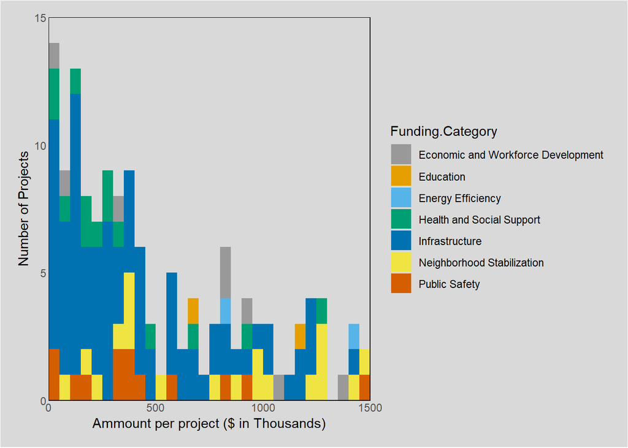

```r
ggplot(stimIdSum) +
  geom_histogram(aes(x = (TotalMoney/1000), fill = Funding.Category),
                 breaks=seq(0, 1500 , by = 50),
                 # colour="black",
                 # fill="purple"
  )+
  scale_fill_manual(values=cbPalette)+
  theme(
    plot.background = element_rect(fill = "#D9D9D9")
    , legend.key = element_rect(fill = "#D9D9D9")
    , legend.background = element_rect(fill="#D9D9D9")

    , panel.background = element_rect(fill = "#D9D9D9",
                                      colour = "#D9D9D9",
                                      size = 0.5, linetype = "solid")
    , panel.border = element_rect(fill = "NA",
                                  colour = "black",
                                  size = 0.5, linetype = "solid")
    , panel.grid.major = element_blank()
    , panel.grid.minor = element_blank()
    , axis.ticks.length = -unit(0, "pt")
    # , axis.title.y = element_text(angle = 0, vjust = 0.5, hjust=0)
  )+
  scale_x_continuous(limits=c(0, 1500), expand = c(0, 0)) +
  scale_y_continuous(limits=c(0, 15), expand = c(0, 0)) +
  theme(plot.margin = unit(c(0.5, 0.5, 0.5, 0.5), "cm"))+
  xlab("Ammount per project ($ in Thousands)")+
  ylab("Number of Projects")
```

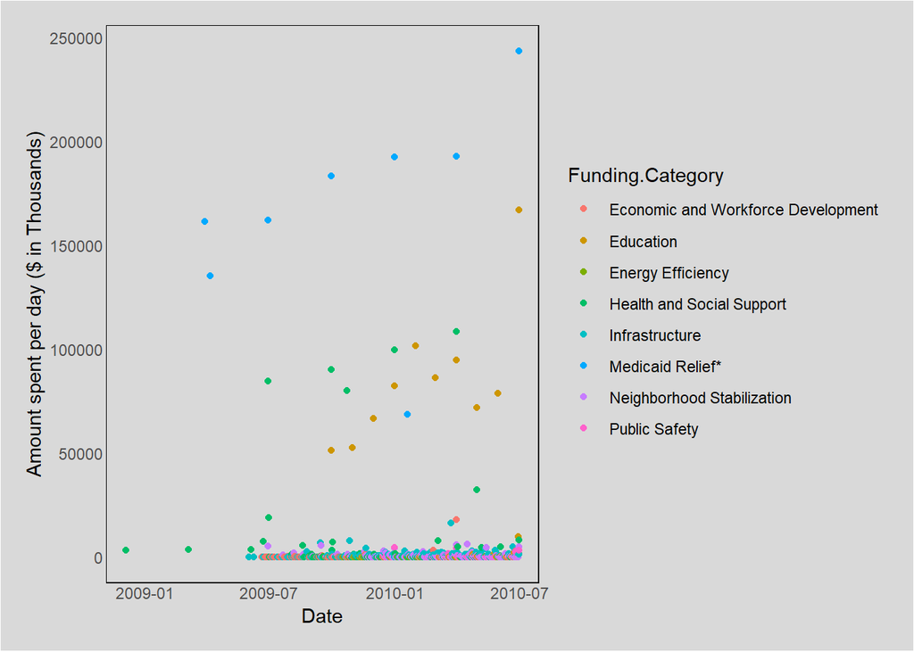

```r
paymentDates <- arraData %>%
  filter(is.na(Payment.Id)==FALSE) %>%
  group_by(Payment.Date, Funding.Category) %>%
  summarise(TotalMoney = sum(Payment.Value), .groups= "keep")




ggplot(paymentDates) +
  geom_point(aes(Payment.Date, (TotalMoney/1000), colour = Funding.Category)
  )+
  # scale_color_manual(values=cbPalette)+
  theme(
    plot.background = element_rect(fill = "#D9D9D9")
    , legend.key = element_rect(fill = "#D9D9D9")
    , legend.background = element_rect(fill="#D9D9D9")

    , panel.background = element_rect(fill = "#D9D9D9",
                                      colour = "#D9D9D9",
                                      size = 0.5, linetype = "solid")
    , panel.border = element_rect(fill = "NA",
                                  colour = "black",
                                  size = 0.5, linetype = "solid")
    , panel.grid.major = element_blank()
    , panel.grid.minor = element_blank()
    , axis.ticks.length = -unit(0, "pt")
    # , axis.title.y = element_text(angle = 0, vjust = 0.5, hjust=0)
  )+
  theme(plot.margin = unit(c(0.5, 0.5, 0.5, 0.5), "cm"))+
  xlab("Date")+
  ylab("Amount spent per day ($ in Thousands)")
```

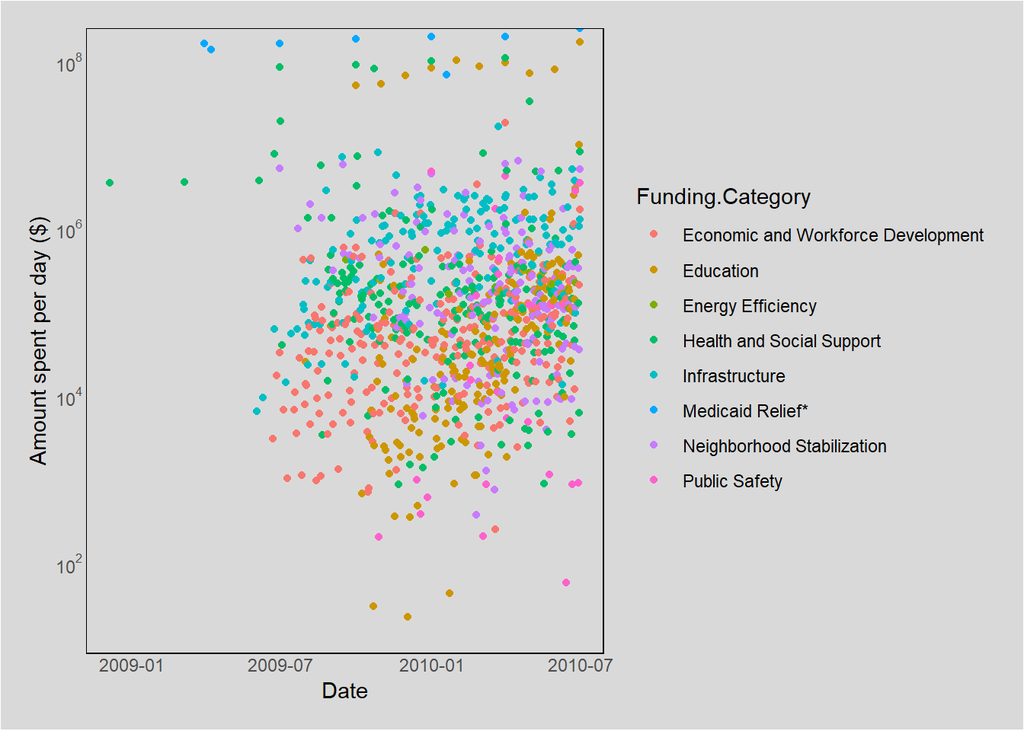

```r
ggplot(paymentDates) +
  geom_point(aes(Payment.Date, TotalMoney, colour = Funding.Category)
  )+
  scale_y_continuous(trans='log10'
                     , breaks=breaks_log()
                     , labels=trans_format('log10', math_format(10^.x))
                     # , limits = ylimits
                     , expand = c(0, 0)
                     , sec.axis = dup_axis(trans = ~.,
                                           name = NULL,
                                           breaks = derive(),
                                           labels = NULL,
                                           guide = derive()
                     )
  )+
  theme(
    plot.background = element_rect(fill = "#D9D9D9")
    , legend.key = element_rect(fill = "#D9D9D9")
    , legend.background = element_rect(fill="#D9D9D9")

    , panel.background = element_rect(fill = "#D9D9D9",
                                      colour = "#D9D9D9",
                                      size = 0.5, linetype = "solid")
    , panel.border = element_rect(fill = "NA",
                                  colour = "black",
                                  size = 0.5, linetype = "solid")
    , panel.grid.major = element_blank()
    , panel.grid.minor = element_blank()
    , axis.ticks.length = -unit(0, "pt")
    # , axis.title.y = element_text(angle = 0, vjust = 0.5, hjust=0)
  )+
  theme(plot.margin = unit(c(0.5, 0.5, 0.5, 0.5), "cm"))+
  xlab("Date")+
  ylab("Amount spent per day ($)")
```

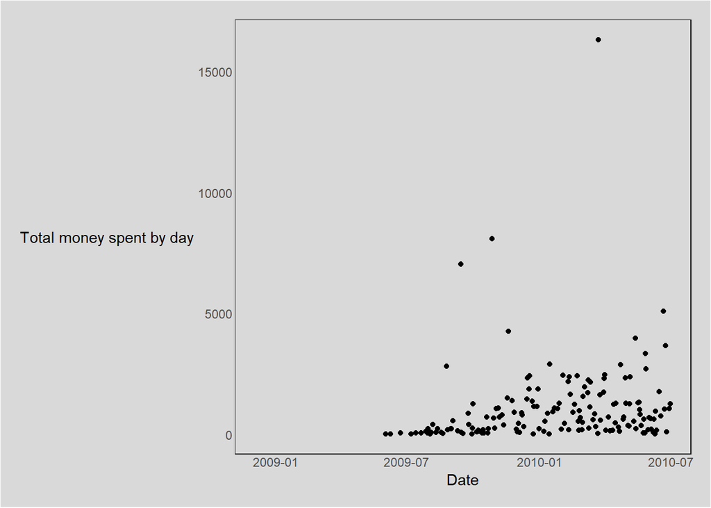

```r
paymentDatesWide <- arraData %>%
  filter(is.na(Payment.Id)==FALSE) %>%
  group_by(Payment.Date, Funding.Category) %>%
  summarise(TotalMoney = sum(Payment.Value), .groups= "keep") %>%
  pivot_wider(names_from = Funding.Category, values_from = TotalMoney)



ggplot(paymentDatesWide) +
  geom_point(aes(x = Payment.Date, y = (`Infrastructure`/1000 ))
  )+
  theme(
    plot.background = element_rect(fill = "#D9D9D9")

    , panel.background = element_rect(fill = "#D9D9D9",
                                      colour = "#D9D9D9",
                                      size = 0.5, linetype = "solid")
    , panel.border = element_rect(fill = "NA",
                                  colour = "black",
                                  size = 0.5, linetype = "solid")
    , panel.grid.major = element_blank()
    , panel.grid.minor = element_blank()
    , axis.ticks.length = -unit(0, "pt")
    , axis.title.y = element_text(angle = 0, vjust = 0.5, hjust=0)
  )+
  # scale_x_continuous(limits=c(0, 1500), expand = c(0, 0)) +
  # scale_y_continuous(limits=c(0, 15), expand = c(0, 0)) +
  theme(plot.margin = unit(c(0.5, 0.5, 0.5, 0.5), "cm"))+
  xlab("Date")+
  ylab("Total money spent by day")
```